# Drugs Classification

Nomin Batbayar & Sevinj Guluyeva

6/3/2022

## Introduction

We have used Logistic regression, K-Nearest Neighbor, and Regularization algorithm for Drugs data set classification. So far the best method with highest Balanced Accuracy was Regularization algorithm. In this report, we are presenting the results of these methods.

## Data preprocessing & Relavant variables

Prior to selecting data for our model, we are normalizing numeric variables and making categorical variables into factor or ordered factor variables.

### Target variable

In the Drug data set target variable is “COCAINE” /consumption_cocaine_last_month/ which is whether if the person used cocaine in last month. We can clearly see from below that we have unbalanced data, less than 10 percent of is “YES”, positive group. So we will use resampling methods further in our models.

```r
colnames(drugs)[21]<-"cocaine"
drugs$cocaine_num[drugs$cocaine=="No"]<-0
drugs$cocaine_num[drugs$cocaine=="Yes"]<-1
drugs$cocaine_num<-as.numeric(drugs$cocaine_num)

tabyl(drugs$cocaine)
```

```
##  drugs$cocaine    n    percent
##             No 1373 0.91533333
##            Yes  127 0.08466667
```

### Numeric variables

#### Histogram

Most of the variable looks normaly distributed, except for Sensation and impulsiveness. We made normalization transformation in this variables.

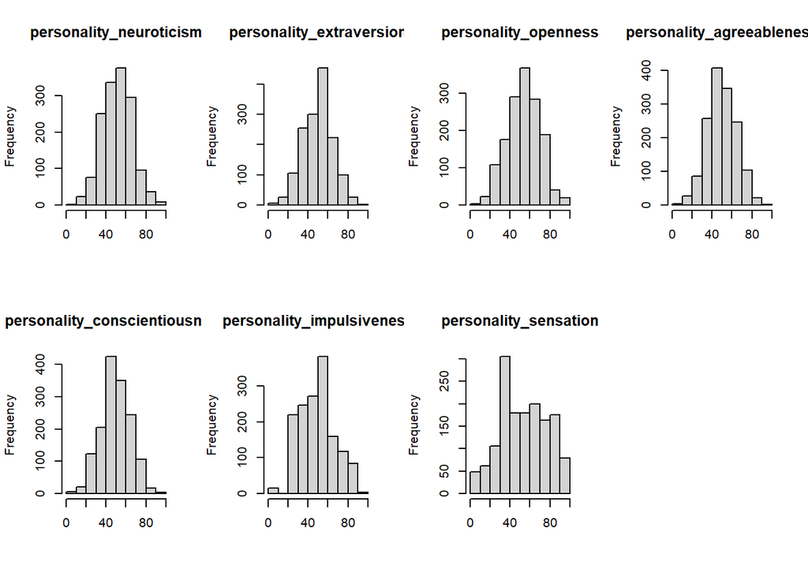

```r
par(mfrow=c(2,4))
for (variable in 7:13) {
  hist(drugs[[variable]], xlab=NULL , main=paste(drugs[variable] %>% colnames()))
}

for (variable in 7:13) {
  drugs[[variable]]<-as.numeric(scale(drugs[[variable]]))
}
```

#### BoxPlots

Below we are showing the box plot graphics of numeric variables to check if there is any significant difference in the 2 group. With the person who used cocaine last month, agreeableness variable is slightly lower but not significant, whereas impulsiveness and sensation is higher. Other variables are not significantly different.

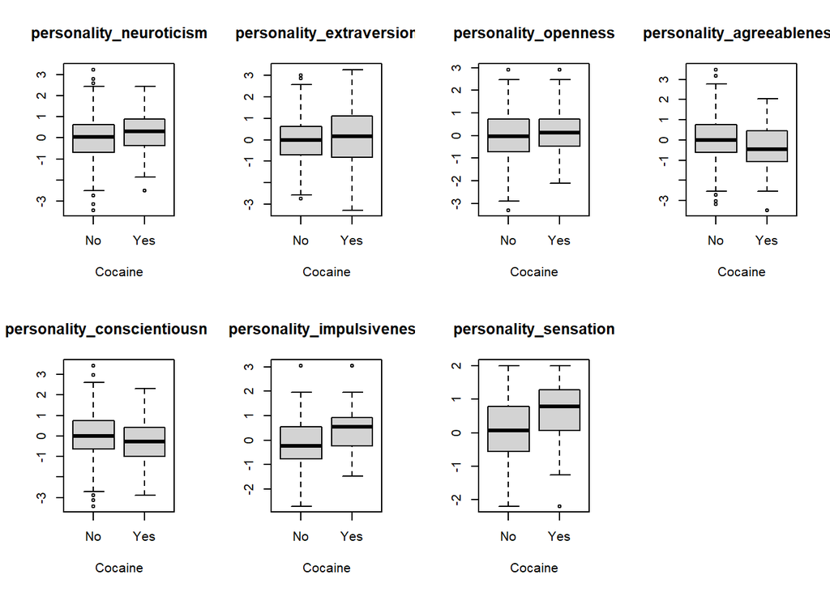

```r
### numeric variables ###
drugs_numeric_vars <- sapply(drugs, is.numeric) %>% which() %>% names()

par(mfrow=c(2,4))
for (variable in 7:13) {
  boxplot(drugs[[variable]]~drugs$cocaine, data=drugs ,  main=paste(drugs[variable] %>% colnames()), xlab="Cocaine", ylab = NULL)
}
par(mfrow=c(1,1))
```

#### Correlation between numeric variables

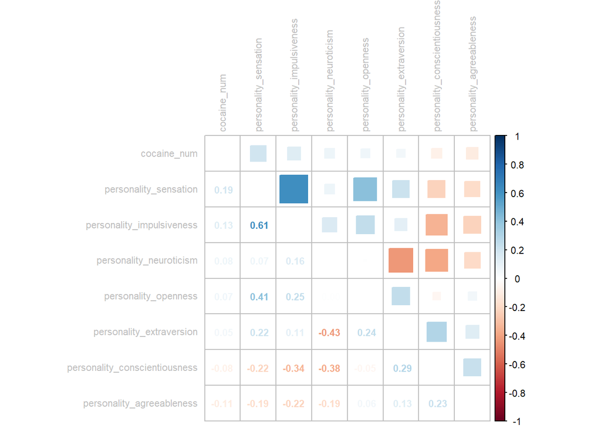

```r
drugs_numeric_correlations <- cor(drugs[, drugs_numeric_vars], use = "pairwise.complete.obs")
drugs_numeric_vars_order <- drugs_numeric_correlations[,"cocaine_num"] %>% sort(decreasing = TRUE) %>%  names()
corrplot.mixed(drugs_numeric_correlations[drugs_numeric_vars_order, drugs_numeric_vars_order],
               upper = "square",
               lower = "number",
               tl.col = "grey", # color of labels (variable names)
               tl.pos = "lt",
               tl.cex = 0.7,
               number.cex = 0.7,
               cl.cex = 0.7)  # position of labels (lt = left and top)
```

### Categorical variables

```r
###### categorical variable #######

drugs$gender<-as.factor(drugs$gender)
drugs$country<-as.factor(drugs$country)
drugs$ethnicity<-as.factor(drugs$ethnicity)
drugs$age<-factor(drugs$age, levels = c("18-24", "25-34", "35-44", "45-54", "55-64", "65+"), ordered = TRUE)

drugs$education<-factor(drugs$education, levels = c("Left school before 16 years", "Left school at 16 years", "Left school at 17 years",
                                                    "Left school at 18 years", "Some college or university, no certificate or degree", "Professional certificate/ diploma",
                                                    "University degree", "Masters degree", "Doctorate degree"),ordered = TRUE)
drugs$education<-fct_collapse(drugs$education, "Secondary or below" = c("Left school before 16 years", "Left school at 16 years", "Left school at 17 years", "Left school at 18 years"))
drugs$education<-fct_collapse(drugs$education, "Bachelor" = c("Professional certificate/ diploma", "University degree"))

for (variable in 14:20) {
  drugs[[variable]]<-factor(drugs[[variable]], levels = c("never used", "used over a decade ago", "used in last decade", "used in last year",
                                                                          "used in last month", "used in last week","used in last day"),ordered = TRUE)}

drug_categorical_vars <- sapply(drugs, is.factor) %>%  which() %>%  names()
```

#### BarPlot

Below we are showing grouped bar plot of each variables with target variable. From ANOVA tab we can see that most associated variables are consumption of amphetamines, mushrooms, cannabis. More recent consumption of this substances is associated with cocaine usage in last month. And less associated variables are chocolate, alcohol and caffeine consumption.

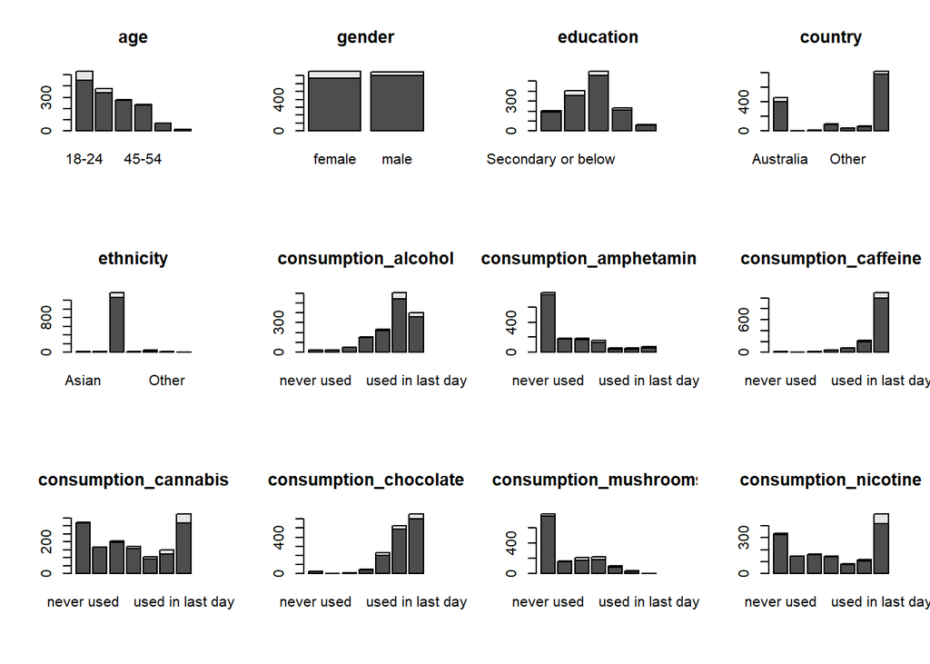

```r
par(mfrow=c(3,4))
for (variable in drug_categorical_vars) {
  barplot(table(drugs$cocaine, drugs[[variable]]), xlab=NULL, main=paste(drugs[variable] %>% colnames()))
}
```

#### ANOVA

```r
drugs_F_anova <- function(categorical_var) {
  anova_ <- aov(drugs$cocaine_num ~ drugs[[categorical_var]])
  return(summary(anova_)[[1]][1, 4])}

drugs_anova_all_categorical<-sapply(drug_categorical_vars, drugs_F_anova) %>% sort(decreasing = TRUE) %>% data.frame()

drugs_anova_all_categorical
```

```
##                                  .
## consumption_amphetamines 22.217012
## consumption_mushrooms    16.242459
## consumption_cannabis     13.912235
## gender                   13.066516
## age                      11.721634
## consumption_nicotine     11.133196
## country                   7.222793
## ethnicity                 3.372292
## education                 2.518828
## consumption_chocolate     2.069451
## consumption_alcohol       1.908593
## consumption_caffeine      1.355063
```

## Classification

In this part we will show classification model results and select best algorithm. We are using Logistic regression, K-Nearest neighbor, and Regularization algorithm for the classification. We are also using cross validation method.

```r
drugs$cocaine<-as.factor(drugs$cocaine)
```

```r
#drugs_split <- createDataPartition(drugs$cocaine,
#                                   p = 0.7,
#                                   list = FALSE)
#drug_train <- drugs[c(drugs_split),]
#drug_test <- drugs[-c(drugs_split),]


#save(list = c("drug_train",
#              "drug_test"),
#     file = "drug_train_test.RData")
```

### Logistic regression

Logistic regression is one of machine learning algorithm, which is used to predict binary dependent variable. It calculates the probability of target variable to be in positive group, with explanatory variables.

#### Feature selection

```r
## Unrestricted model
model_im<-glm(cocaine~., data = drug_train[,-c(1,22)], family=binomial(link="logit"))
## Restricted impulsiveness
model_im_2<-glm(cocaine~., data = drug_train[,-c(1,12,22)], family=binomial(link="logit"))
## Restricted sensation
model_im_3<-glm(cocaine~., data = drug_train[,-c(1,13,22)], family=binomial(link="logit"))
## Restricted consumption of alchohol, caffeine, chocolate
model_im_4<-glm(cocaine~., data = drug_train[,-c(1,  14, 16, 18, 22)], family=binomial(link="logit"))

model_2<-lrtest(model_im, model_im_2)
model_3<-lrtest(model_im, model_im_3)
model_4<-lrtest(model_im, model_im_4)

lrtest_result<- data.frame(model_2=model_2$`Pr(>Chisq)`[2], model_3=model_3$`Pr(>Chisq)`[2], model_4=model_4$`Pr(>Chisq)`[2])

lrtest_result
```

```
##     model_2   model_3    model_4
## 1 0.8417299 0.2542668 0.04926117
```

#### Imbalanced & Upsamling & SMOTE code

```r
fiveStats <- function(...) c(twoClassSummary(...),
                             defaultSummary(...))

ctrl_cv5 <- trainControl( method = "cv",classProbs = TRUE, summaryFunction = fiveStats)


# up-sampling
set.seed(987654321)

ctrl_cv5$sampling <- "up"
drug_train_logit_up <-train(cocaine ~ ., data = drug_train[,-c(1,  12, 13,  22)],
        method = "glm", family = "binomial", trControl = ctrl_cv5)

predict_logit_up<-predict(drug_train_logit_up, drug_train)

# SMOTE
set.seed(987654321)

ctrl_cv5$sampling <- "smote"
drug_train_logit_smote <- train(cocaine ~ ., data = drug_train[,-c(1,  12, 13,  22)],
        method = "glm", family = "binomial", trControl = ctrl_cv5)

predict_logit_smote<-predict(drug_train_logit_smote, drug_train)

models_logit <- ls(pattern = "drug_train_logit")
```

#### Imbalanced & Upsamling & SMOTE evaluation

Based on the Balanced Accuracy value of prediction on the training sample data UP sampling method is best.

```r
table(predict_logit_smote, drug_train$cocaine)
```

```
##
## predict_logit_smote  No Yes
##                 No  761  14
##                 Yes 201  75
```

```r
table(predict_logit_up, drug_train$cocaine)
```

```
##
## predict_logit_up  No Yes
##              No  749  11
##              Yes 213  78
```

```r
models_logit %>% sapply(function(x) get(x) %>% predict(newdata = drug_train) %>%
           summary_binary_class(level_positive = "Yes",
                                level_negative = "No",
                                real = drug_train$cocaine)) %>% t()
```

```
##                        Accuracy Sensitivity Specificity Pos Pred Value
## drug_train_logit_smote  0.79543      0.8427     0.79106        0.27174
## drug_train_logit_up     0.78687      0.8764     0.77859        0.26804
##                        Neg Pred Value      F1 Balanced Accuracy
## drug_train_logit_smote        0.98194 0.41096           0.81688
## drug_train_logit_up           0.98553 0.41053           0.82750
```

### KNN

K-Nearest neighbour is used for classification. It calculates category of the data within its nearest neighbor.

#### Optimal K value

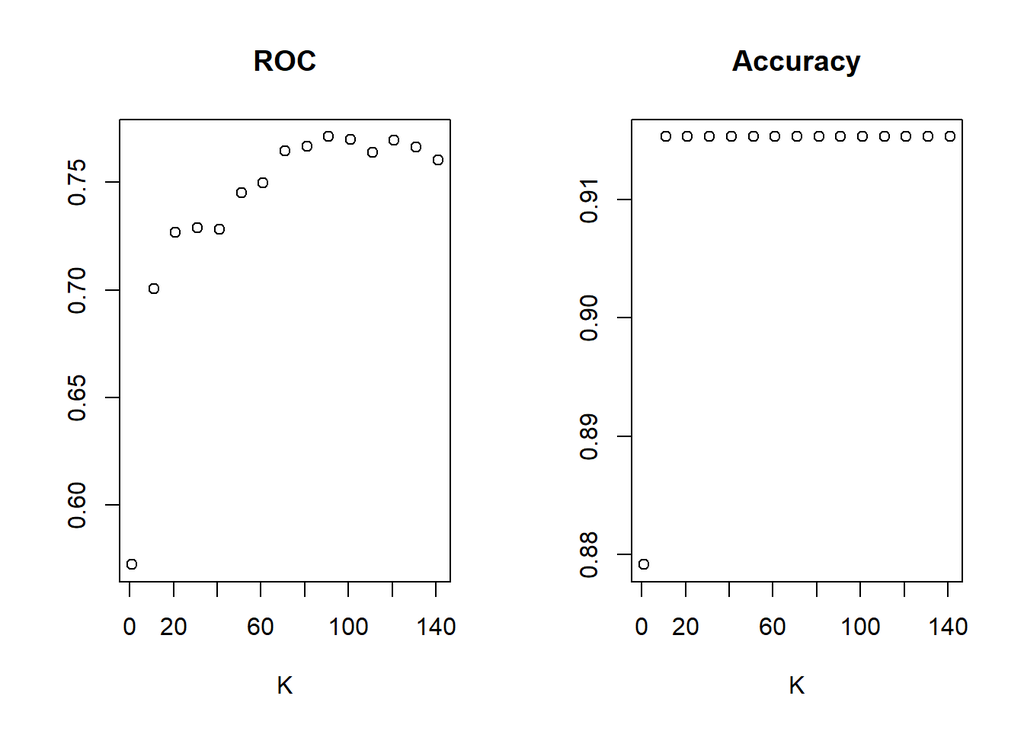

```r
fiveStats <- function(...) c(twoClassSummary(...),
                             defaultSummary(...))
ctrl_cv <- trainControl(method = "cv", classProbs = TRUE, summaryFunction = fiveStats)

different_k <- data.frame(k = seq(1, 150, 10))
set.seed(987654321)
drug_knn_tuned <- train(cocaine ~ ., data = drug_train[,-c(1, 12, 13, 22)],
        method = "knn", trControl = ctrl_cv, tuneGrid = different_k)

par(mfrow=c(1,2))
plot(drug_knn_tuned$results$k, drug_knn_tuned$results$ROC, ylab="",xlab="K", main="ROC")
plot(drug_knn_tuned$results$k, drug_knn_tuned$results$Accuracy,ylab="",xlab="K", main="Accuracy")
```

```r
par(mfrow=c(1,1))

k<-drug_knn_tuned$results$k[drug_knn_tuned$results$ROC==max(drug_knn_tuned$results$ROC)]
k
```

```
## [1] 91
```

#### KNN with optimal K

With optimal K value we estimated KNN with smote and up sampling.

```r
fiveStats <- function(...) c(twoClassSummary(...),
                             defaultSummary(...))

k_value <- data.frame(k =k)
ctrl_cv5 <- trainControl(method = "cv",classProbs = TRUE, summaryFunction = fiveStats)
ctrl_cv5$sampling<-"smote"
drug_train_knn_smote <- train(cocaine ~ ., data = drug_train[,-c(1, 12, 13,  22)],
        method = "knn",trControl = ctrl_cv5, tuneGrid = k_value)

predict_knn_smote<-predict(drug_train_knn_smote, drug_train)

ctrl_cv5$sampling<-"up"
drug_train_knn_up <- train(cocaine ~ ., data = drug_train[,-c(1,  12, 13, 22)],
        method = "knn",trControl = ctrl_cv5, tuneGrid = k_value)
predict_knn_up<-predict(drug_train_knn_up, drug_train)


models_knn <- ls(pattern = "drug_train_knn")
```

#### KNN evaluation

We can see that KNN method is predicting worse than logistic regression.

```r
models_knn %>% sapply(function(x) get(x) %>% predict(newdata = drug_train) %>%
           summary_binary_class(level_positive = "Yes",
                                level_negative = "No",
                                real = drug_train$cocaine)) %>% t()
```

```
##                      Accuracy Sensitivity Specificity Pos Pred Value
## drug_train_knn_smote  0.51094     0.93258     0.47193        0.14044
## drug_train_knn_up     0.70124     0.76404     0.69543        0.18837
##                      Neg Pred Value      F1 Balanced Accuracy
## drug_train_knn_smote        0.98696 0.24412           0.70226
## drug_train_knn_up           0.96957 0.30222           0.72974
```

### Regularization

We would like to see if we make the prediction of logit regression with help of regularization method. Lasso regularization works better with a few significant variables, and the rest of the variable’s coefficients are very small. With the help of lambda parameter, we can include all variables. Because it will shrink the unrelevant variable coefficients to 0. So that if we might excluded relevant or included unrelevant variables in logit regression, Lasso will fix this problem.

#### Optimal lambda value

```r
options(contrasts = c("contr.treatment",  # for non-ordinal factors
                      "contr.treatment")) # for ordinal factors



ctrl_cv5 <- trainControl(method = "cv",
                         number = 5)
lambdas <- seq(0, 1, 0.001)
parameters <- expand.grid(alpha = 1, # lasso
                                lambda = lambdas)
set.seed(123456789)
drug_lasso_tune <- train(cocaine ~ .,
                      data = drug_train[,-c(1,22)],
                      method = "glmnet",
                      family = "binomial",
                      tuneGrid = parameters,
                      trControl = ctrl_cv5)


l<-min(drug_lasso_tune$results$lambda[drug_lasso_tune$results$Accuracy==max(drug_lasso_tune$results$Accuracy)])
l
```

```
## [1] 0.013
```

#### Optimal lambda

```r
ctrl_cv5 <- trainControl(method = "cv", classProbs = TRUE, summaryFunction = fiveStats)

ctrl_cv5$sampling<-"up"
drug_train_lasso_up <- train(cocaine ~ .,
                           data = drug_train[,-c(1,22)],
                           method = "glmnet",
                           family = "binomial",
                           tuneGrid = expand.grid(alpha = 1,
                                                  lambda = l),
                           trControl = ctrl_cv5)

predict_lasso_up <- predict(drug_train_lasso_up, drug_train)
table(predict_lasso_up, drug_train$cocaine)
```

```
##
## predict_lasso_up  No Yes
##              No  717  14
##              Yes 245  75
```

```r
ctrl_cv5$sampling<-"smote"
drug_train_lasso_smote <- train(cocaine ~ .,
                           data = drug_train[,-c(1,22)],
                           method = "glmnet",
                           family = "binomial",
                           tuneGrid = expand.grid(alpha = 1,
                                                  lambda = l),
                           trControl = ctrl_cv5)

predict_lasso_smote <- predict(drug_train_lasso_smote, drug_train)
table(predict_lasso_smote, drug_train$cocaine)
```

```
##
## predict_lasso_smote  No Yes
##                 No  734  15
##                 Yes 228  74
```

```r
models_lasso <- ls(pattern = "drug_train_lasso")
```

#### Regularization evaluation

We can see that Lasso, prediction accuracy falled from logistic regression.

```r
models_lasso %>% sapply(function(x) get(x) %>% predict(newdata = drug_train) %>%
           summary_binary_class(level_positive = "Yes",
                                level_negative = "No",
                                real = drug_train$cocaine)) %>% t()
```

```
##                        Accuracy Sensitivity Specificity Pos Pred Value
## drug_train_lasso_smote  0.76879     0.83146     0.76299        0.24503
## drug_train_lasso_up     0.75357     0.84270     0.74532        0.23437
##                        Neg Pred Value      F1 Balanced Accuracy
## drug_train_lasso_smote        0.97997 0.37852           0.79723
## drug_train_lasso_up           0.98085 0.36675           0.79401
```

### Evaluation of all models

We know that best model predicted with training data is logistic regression with up sampling. However below results show that lasso method with up sampling is better.

```r
models_all <- ls(pattern = "drug_train_")


models_all %>% sapply(function(x) get(x) %>% predict(newdata = drug_test) %>%
           summary_binary_class(level_positive = "Yes",
                                level_negative = "No",
                                real = drug_test$cocaine)) %>% t()
```

```
##                        Accuracy Sensitivity Specificity Pos Pred Value
## drug_train_knn_smote    0.48552     0.86842     0.45012        0.12741
## drug_train_knn_up       0.66370     0.65789     0.66423        0.15337
## drug_train_lasso_smote  0.72606     0.78947     0.72019        0.20690
## drug_train_lasso_up     0.73497     0.86842     0.72263        0.22449
## drug_train_logit_smote  0.76169     0.76316     0.76156        0.22835
## drug_train_logit_up     0.73497     0.73684     0.73479        0.20438
##                        Neg Pred Value      F1 Balanced Accuracy
## drug_train_knn_smote          0.97368 0.22222           0.65927
## drug_train_knn_up             0.95455 0.24876           0.66106
## drug_train_lasso_smote        0.97368 0.32787           0.75483
## drug_train_lasso_up           0.98344 0.35676           0.79552
## drug_train_logit_smote        0.97205 0.35152           0.76236
## drug_train_logit_up           0.96795 0.32000           0.73582
```

### Test data prediction

In this part we are applying same data preprocessing rules and predicting the test data with lasso model and saving the output to csv.

```r
drugs_test<-read_csv("C:/Users/nomin/OneDrive/Desktop/DSBA/2.5. Machine learning 1/_assessment_data_and_desctiption/drugs_test.csv")


for (variable in 7:13) {
  drugs_test[[variable]]<-as.numeric(scale(drugs_test[[variable]]))
}

drugs_test$gender<-as.factor(drugs_test$gender)
drugs_test$country<-as.factor(drugs_test$country)
drugs_test$ethnicity<-as.factor(drugs_test$ethnicity)
drugs_test$age<-factor(drugs_test$age, levels = c("18-24", "25-34", "35-44", "45-54", "55-64", "65+"), ordered = TRUE)

drugs_test$education<-factor(drugs_test$education, levels = c("Left school before 16 years", "Left school at 16 years", "Left school at 17 years",
                                                    "Left school at 18 years", "Some college or university, no certificate or degree", "Professional certificate/ diploma",
                                                    "University degree", "Masters degree", "Doctorate degree"),ordered = TRUE)
drugs_test$education<-fct_collapse(drugs_test$education, "Secondary or below" = c("Left school before 16 years", "Left school at 16 years", "Left school at 17 years", "Left school at 18 years"))
drugs_test$education<-fct_collapse(drugs_test$education, "Bachelor" = c("Professional certificate/ diploma", "University degree"))

for (variable in 14:20) {
  drugs_test[[variable]]<-factor(drugs_test[[variable]], levels = c("never used", "used over a decade ago", "used in last decade", "used in last year",
                                                                          "used in last month", "used in last week","used in last day"),ordered = TRUE)}


drugs_test$consumption_cocaine_last_month<-predict(drug_train_lasso_up, drugs_test)

write_excel_csv2(drugs_test, "drugs_test_prediction.csv", delim=",")
```